# CA Housing

Mladen Kolar (mkolar@chicagobooth.edu)

Our goal will be to predict `log(MedVal)` for census tracts.

```r
ca <- read.csv("CaliforniaHousing.csv")
for (i in c(7,8,9)) {
  xq <- quantile(ca[,i], c(0.001, 0.99))
  ca <- ca[ca[,i] >= xq[1] & ca[,i] <= xq[2], ]
}
```

```r
train.index = sample(nrow(ca), 5000)
ca.train = ca[train.index,]
ca.test = ca[-train.index,]
```

## CART fit

Income is dominant, with location important for low income.

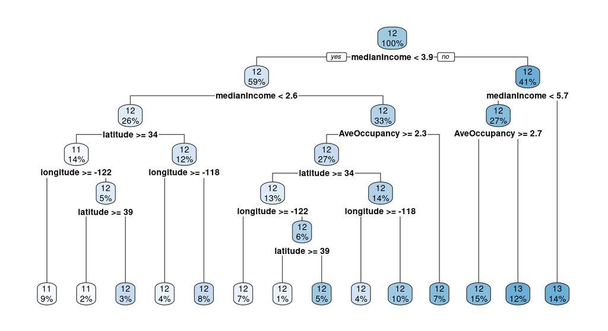

```r
ca.tree <- rpart(logMedVal ~ ., data=ca.train, control=rpart.control(xval=5))
rpart.plot(ca.tree)
```

```r
(ca.tree.size = length(unique(ca.tree$where)))
```

```
## [1] 14
```

Now lets try to prune it back.

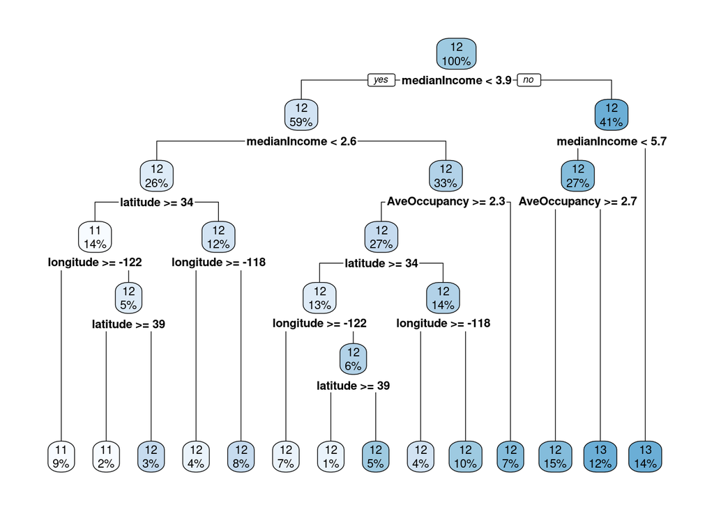

```r
bestcp = ca.tree$cptable[ which.min(ca.tree$cptable[,"xerror"]), "CP" ]
ca.tree.pruned = prune(ca.tree, cp=bestcp)
rpart.plot(ca.tree.pruned)
```

What is the size of the best tree found via CV?

```r
(ca.tree.pruned.size = length(unique(ca.tree.pruned$where)))
```

```
## [1] 14
```

- Same size! (No pruning necessary.)

## Random forest fit

No tree to visualize, but we can make a so-called **variable importance** plot.

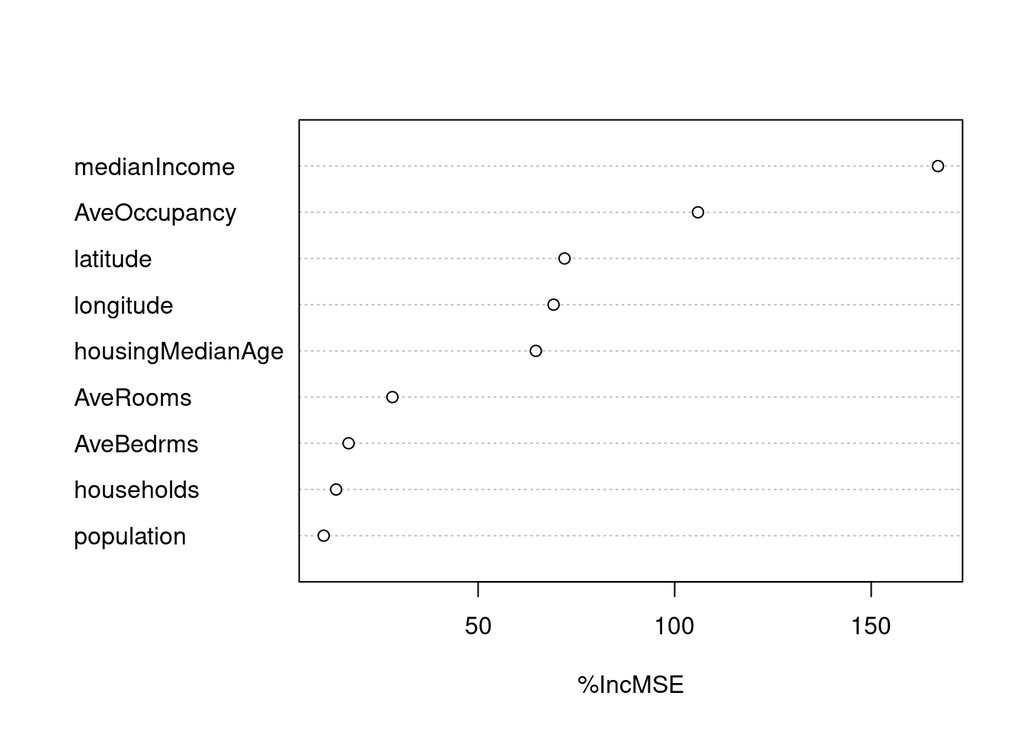

```r
ca.bag <- randomForest(logMedVal ~ .,data=ca.train,
                      mtry=9, ntree=250, nodesize=25, keep.inbag=TRUE, importance=TRUE)
varImpPlot(ca.bag, type=1, main="")
```

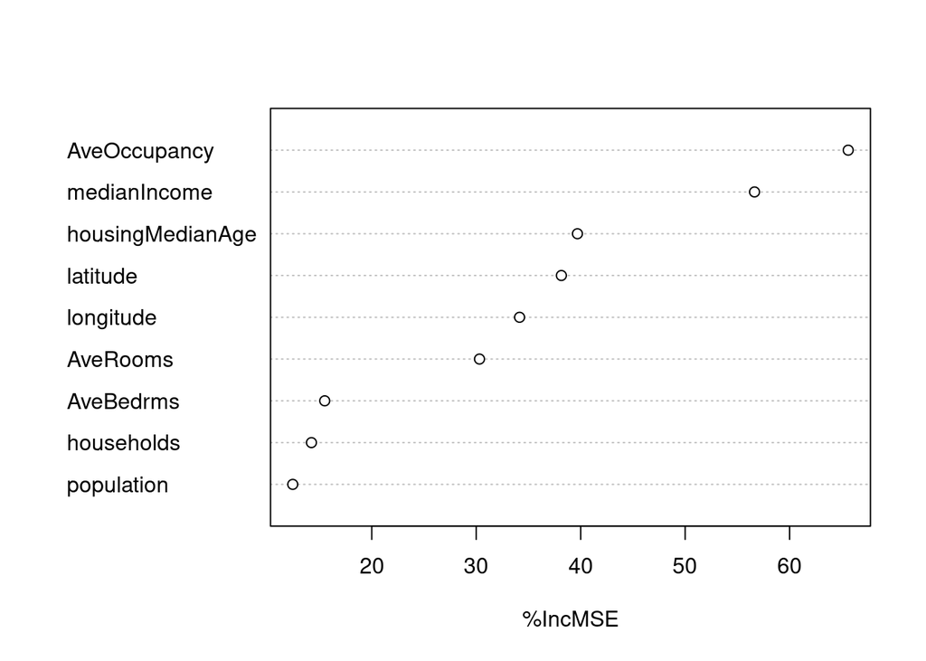

```r
ca.rf <- randomForest(logMedVal ~ .,data=ca.train,
                      mtry=3, ntree=250, nodesize=25, keep.inbag=TRUE, importance=TRUE)
varImpPlot(ca.rf, type=1, main="")
```

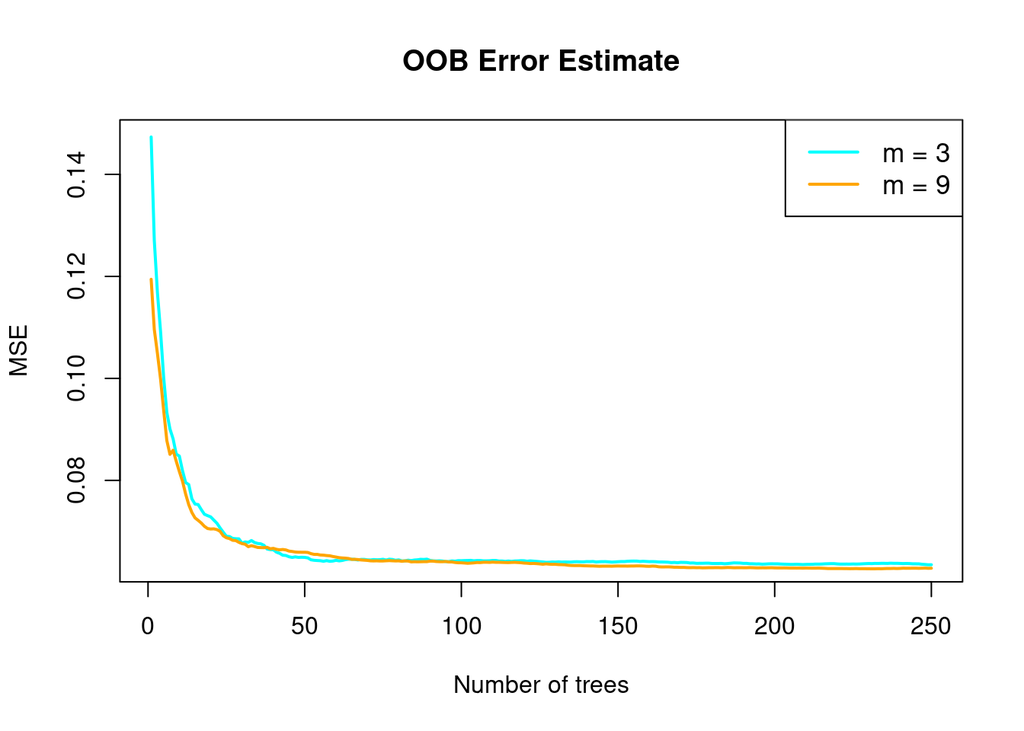

```r
plot(ca.rf$mse, type='l', lwd=2, col='cyan', xlab='Number of trees', ylab='MSE',
         main='OOB Error Estimate')
lines(ca.bag$mse, lwd=2, col='orange')
legend("topright", legend=c('m = 3', 'm = 9'),
       col=c("cyan", "orange"), lwd=2, cex=1.1)
```

Let us also compute the validation error.

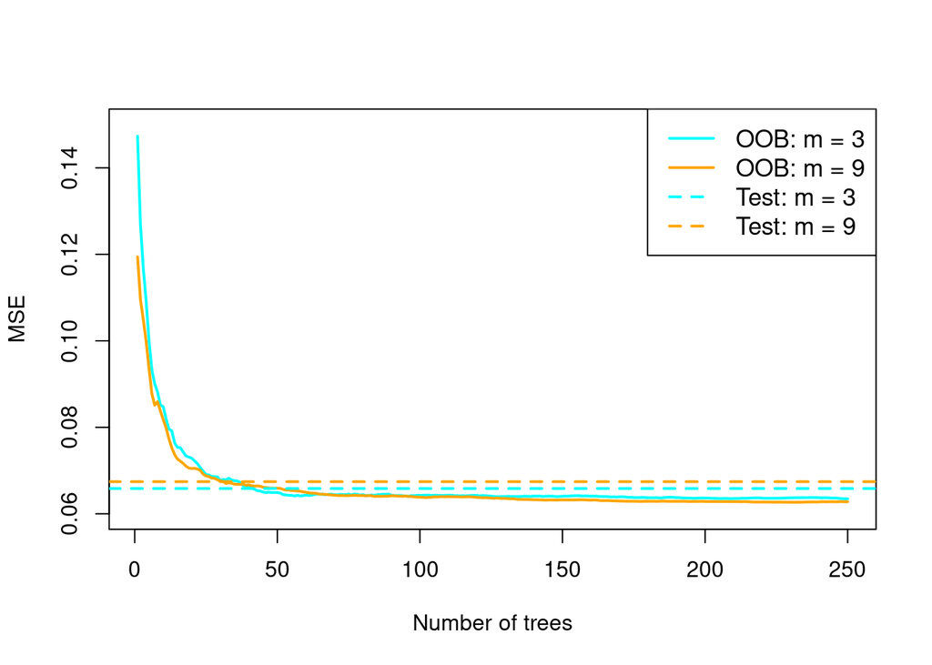

```r
# error for random forest model
yhat = predict(ca.rf, newdata=ca.test)
test.error.rf = var(yhat - ca.test$logMedVal)

# error for bagged model
yhat = predict(ca.bag, newdata=ca.test)
test.error.bag = var(yhat - ca.test$logMedVal)

plot(ca.rf$mse, type='l', lwd=2, col='cyan', xlab='Number of trees', ylab='MSE',
         main='', ylim=c(0.06, 0.15))
lines(ca.bag$mse, lwd=2, col='orange')
abline(h=test.error.rf, lwd=2, lty=2, col='cyan')
abline(h=test.error.bag, lwd=2, lty=2, col='orange')
legend("topright", legend=c('OOB: m = 3', 'OOB: m = 9', 'Test: m = 3', 'Test: m = 9'),
       col=c("cyan", "orange", "cyan", "orange"), lwd=2, cex=1.1, lty=c(1,1,2,2))
```

## Partial dependence plot

For more information, see:

- Section 10.13.2 of ESL.
- [Interpretabe Machine Learning](https://christophm.github.io/interpretable-ml-book/index.html) by Christoph Molnar, Section 5.1

We can attempt to understand how the response variable changes based on the important variables identified above.

The **partial dependence plot** (PDP) shows the marginal effect one or two features have on the predicted outcome.

The average or partial dependence of $f(X)$ on $X_S$ is given as
$$f_S(X_S) = E_{X_C} f(X_S, X_C).$$

The partial dependence function is estimated by calculating averages in the training data
$$\tilde f_S(X_S) = \frac{1}{n} \sum_{i=1}^n \hat f(X_S, x_{iC}).$$

Useful description when $X_S$ do not have *strong interactions* with those in $X_C$.

**Interpretation**: Partial effect of $X_S$ after accounting for the average effect of other variables.

- They are **not** the effect of $X_S$ on $f(X)$ ignoring the effect of $X_C$

**Pros**:

- Computation is intuitive. The partial dependence function at a particular feature value represents the average prediction if we force all data points to assume that feature value.
- The partial dependence plot shows how the average prediction in your dataset changes when the j-th feature is changed (if feature is uncorrelated).

**Cons**:

- Some partial dependence plots do not show the feature distribution. Omitting the distribution can be misleading, because you might overinterpret regions with almost no data.
- *Heterogeneous effects* might be **hidden** because partial dependence plots only show the average marginal effects.
  - for half your data points a feature has a positive association
  - for the other half the feature has a negative association
  - The PD curve could be a horizontal line, since the effects of both halves of the dataset could cancel each other out.

### Examples

There are many packages that can create partial dependence plots. For example, the package `randomForest` comes with its own function `randomForest::partialPlot()` that can be used to visualize PD plots for one variable.

I will show you examples using two packages [`iml`](https://cran.r-project.org/web/packages/iml/index.html) and [`pdp`](https://cran.r-project.org/web/packages/pdp/index.html).

Let us start by using `iml` package.

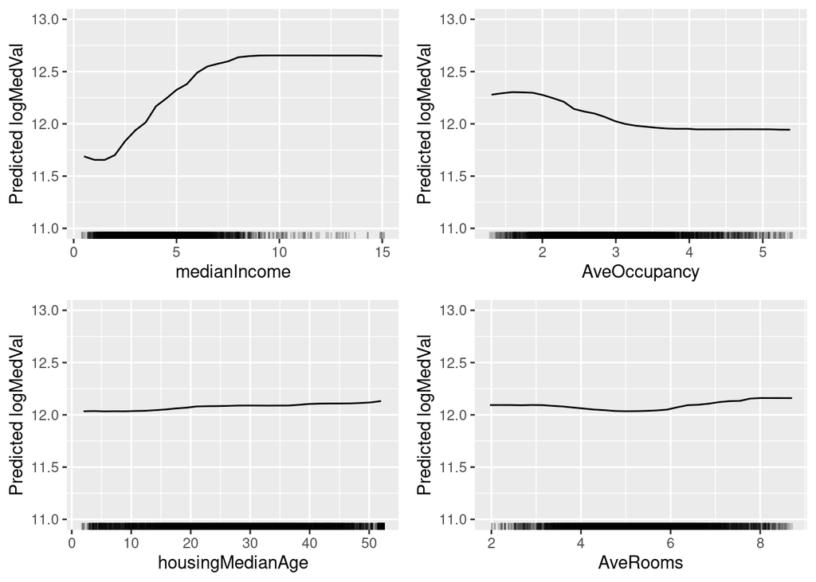

```r
mod <- Predictor$new(ca.rf, data = ca.train)
eff <- FeatureEffect$new(mod,
          feature = "medianIncome",
          method = "pdp",
          grid.size = 30
          )

p1 <- plot(eff, ylim=c(11,13))
eff$set.feature("AveOccupancy")
p2 <- plot(eff, ylim=c(11,13))
eff$set.feature("housingMedianAge")
p3 <- plot(eff, ylim=c(11,13))
eff$set.feature("AveRooms")
p4 <- plot(eff, ylim=c(11,13))

gridExtra::grid.arrange(p1, p2, p3, p4, ncol = 2)
```

Is it surprising that the partial effect of `housingMedianAge` is flat, despite the variable being rather relevant?

## Individual Conditional Expectation (ICE)

See *Peeking Inside the Black Box: Visualizing Statistical Learning with Plots of Individual Conditional Expectation* by *Alex Goldstein, Adam Kapelner, Justin Bleich, Emil Pitkin* for more details. [PDF](https://arxiv.org/abs/1309.6392)

Individual Conditional Expectation (ICE) plots display one line per instance that shows how the instance’s prediction changes when a feature changes.

- Equivalent of partial dependence plot, but for individual data.

One line represents the predictions for one instance if we vary the feature of interest.

Partial dependence plots can obscure a heterogeneous relationship created by interactions. ICE curves can uncover heterogeneous relationships.

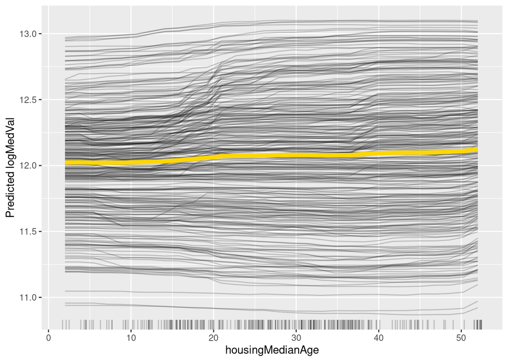

```r
mod <- Predictor$new(ca.rf, data = ca.train[sample(nrow(ca.train), 300), ])
eff <- FeatureEffect$new(mod,
          feature = "housingMedianAge",
          method = "pdp+ice",
          grid.size = 30
          )
plot(eff)
```

When the curves have a wide range of intercepts and are consequently “stacked” on each other, heterogeneity in the model can be difficult to discern.

We can compute the centered ICE plot, which removes level effects.

For each curve $\tilde f^{(i)}$ in the ICE plot, the corresponding centered-ICE curve is given by
$$\tilde f^{(i)}_{cent} = \tilde f^{(i)} - \hat f(x^*, x_{iC})$$

- $\hat f$ denotes the fitted model
- the point $(x^*, \hat f(x^*, x_{iC}))$ acts as a “base case” for each curve
- If $x^*$ is the minimum value of $\{x_{iS}\}$, then all curves originate at 0, thus removing the differences in level due to the different $x_{iC}$’s.

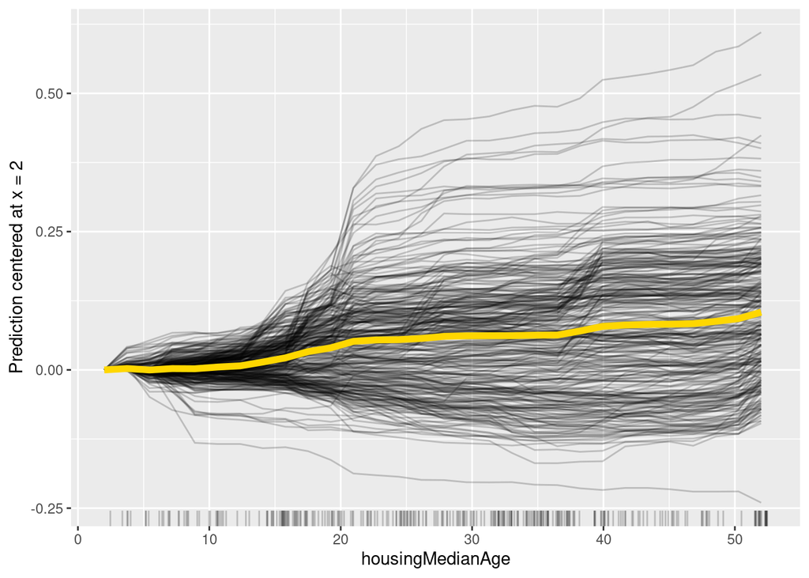

```r
mod <- Predictor$new(ca.rf, data = ca.train[sample(nrow(ca.train), 300), ])
eff <- FeatureEffect$new(mod,
          feature = "housingMedianAge",
          center.at = min(ca.train$housingMedianAge),
          method = "pdp+ice",
          grid.size = 30
          )
plot(eff)
```

Let me now show you how to use `pdp` package.

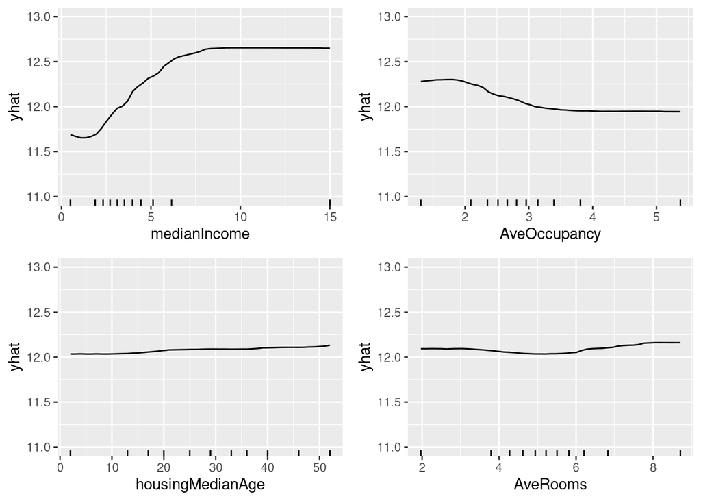

```r
p1 = ca.rf %>%
    partial(pred.var = "medianIncome") %>%
    autoplot(rug=T, train=ca.train) + ylim(11, 13)

p2 = ca.rf %>%
    partial(pred.var = "AveOccupancy") %>%
    autoplot(rug=T, train=ca.train) + ylim(11, 13)


p3 = ca.rf %>%
    partial(pred.var = "housingMedianAge") %>%
    autoplot(rug=T, train=ca.train) + ylim(11, 13)

p4 = ca.rf %>%
    partial(pred.var = "AveRooms") %>%
    autoplot(rug=T, train=ca.train) + ylim(11, 13)

gridExtra::grid.arrange(p1, p2, p3, p4, ncol = 2)
```

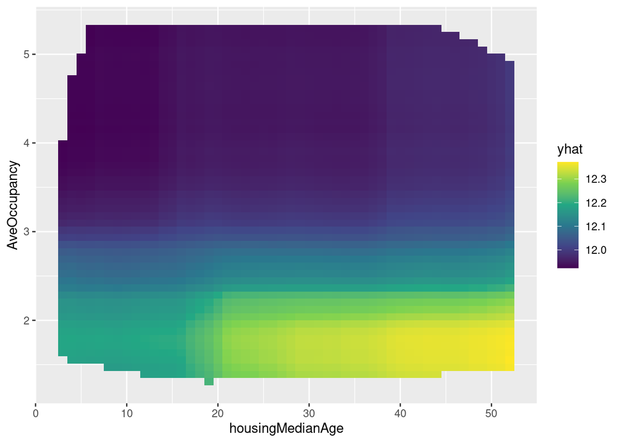

```r
ca.rf %>%
  partial(pred.var = c("housingMedianAge", "AveOccupancy"), chull = TRUE) %>%
  autoplot(rug=T, train=ca.train)
```

Compute PDP for longitude and latitude.

```r
pdp.ll = partial(ca.rf, pred.var = c("longitude", "latitude"), chull = TRUE, train=ca.train)
```

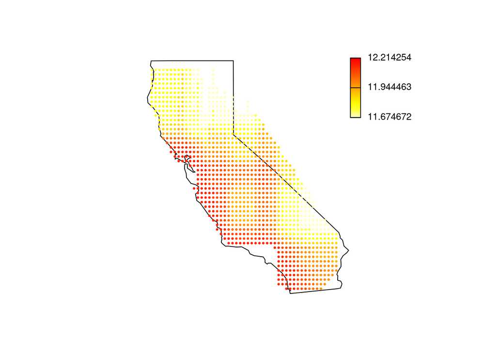

```r
yhat.colmap = heat.colors(10)[10:1]
yhat.breaks = quantile(pdp.ll[,3], seq(0.05, 0.95, by=0.1))
yhat.map <- function(y)
  return(yhat.colmap[cut(drop(y),yhat.breaks)])

map('state', 'california'); points(pdp.ll[,1:2], col=yhat.map(pdp.ll[,3]), pch=20, cex=.5)
gradientLegend(yhat.breaks, yhat.colmap)
```

## GBM Fit

```r
gbm.stump = gbm(logMedVal~., data=ca.train, distribution='gaussian',
               interaction.depth=1,
               n.trees=5000,
               shrinkage=0.01,
               cv.folds = 5,
               n.cores = 1,
               verbose = FALSE)
```

```
## CV: 1
## CV: 2
## CV: 3
## CV: 4
## CV: 5
```

```r
print(gbm.stump)
```

```
## gbm(formula = logMedVal ~ ., distribution = "gaussian", data = ca.train,
##     n.trees = 5000, interaction.depth = 1, shrinkage = 0.01,
##     cv.folds = 5, verbose = FALSE, n.cores = 1)
## A gradient boosted model with gaussian loss function.
## 5000 iterations were performed.
## The best cross-validation iteration was 5000.
## There were 9 predictors of which 9 had non-zero influence.
```

Get variable importance

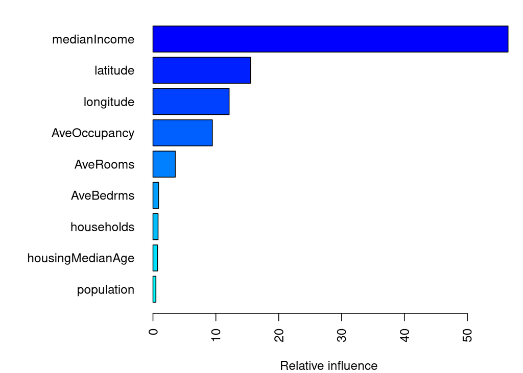

```
##                               var rel.inf
## medianIncome         medianIncome  56.474
## latitude                 latitude  15.525
## longitude               longitude  12.112
## AveOccupancy         AveOccupancy   9.445
## AveRooms                 AveRooms   3.553
## AveBedrms               AveBedrms   0.887
## households             households   0.812
## housingMedianAge housingMedianAge   0.731
## population             population   0.460
```

```r
par(mar=c(4,10,1,1))
summary(gbm.stump, las=2)
```

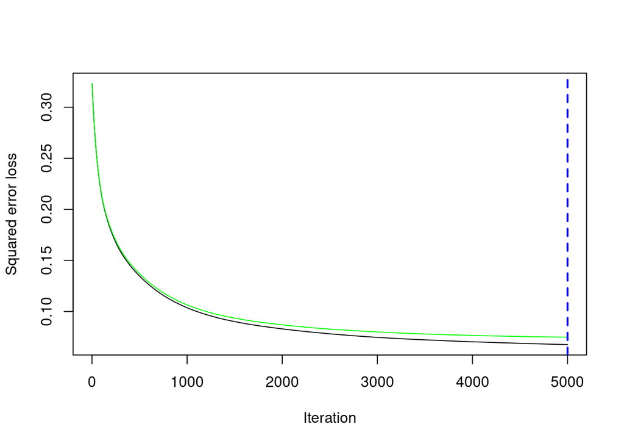

```
## [1] 5000
```

```r
gbm.perf(gbm.stump, method="cv")
```

```r
gbm.d.3 = gbm(logMedVal~., data=ca.train, distribution='gaussian',
               interaction.depth=3,
               n.trees=5000,
               shrinkage=0.01,
               cv.folds = 5,
               n.cores = 1,
               verbose = FALSE)
```

```
## CV: 1
## CV: 2
## CV: 3
## CV: 4
## CV: 5
```

```r
print(gbm.d.3)
```

```
## gbm(formula = logMedVal ~ ., distribution = "gaussian", data = ca.train,
##     n.trees = 5000, interaction.depth = 3, shrinkage = 0.01,
##     cv.folds = 5, verbose = FALSE, n.cores = 1)
## A gradient boosted model with gaussian loss function.
## 5000 iterations were performed.
## The best cross-validation iteration was 5000.
## There were 9 predictors of which 9 had non-zero influence.
```

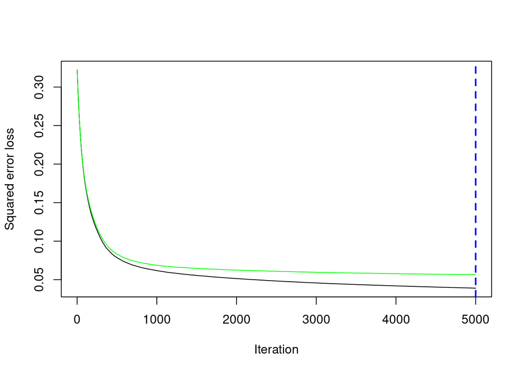

```
## [1] 5000
```

```r
gbm.perf(gbm.d.3, method="cv")
```

Let us also compute the validation error.

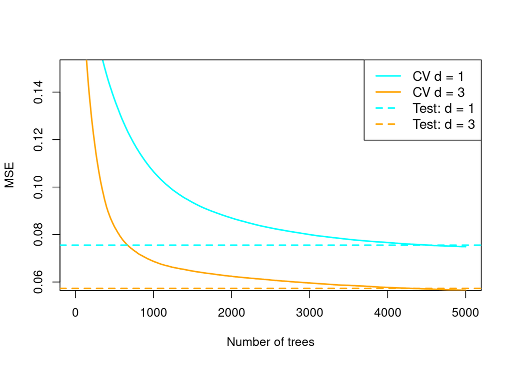

```r
# error for random forest model
yhat = predict(gbm.stump, newdata=ca.test, n.trees=5000)
test.error.gbm.stump = var(yhat - ca.test$logMedVal)

# error for bagged model
yhat = predict(gbm.d.3, newdata=ca.test, n.trees=5000)
test.error.gbm.d.3 = var(yhat - ca.test$logMedVal)

plot(gbm.stump$cv.error, type='l', lwd=2, col='cyan', xlab='Number of trees', ylab='MSE',
         main='', ylim=c(0.06, 0.15))
lines(gbm.d.3$cv.error, lwd=2, col='orange')
abline(h=test.error.gbm.stump, lwd=2, lty=2, col='cyan')
abline(h=test.error.gbm.d.3, lwd=2, lty=2, col='orange')
legend("topright", legend=c('CV d = 1', 'CV d = 3', 'Test: d = 1', 'Test: d = 3'),
       col=c("cyan", "orange", "cyan", "orange"), lwd=2, cex=1.1, lty=c(1,1,2,2))
```

### Partial dependence plot

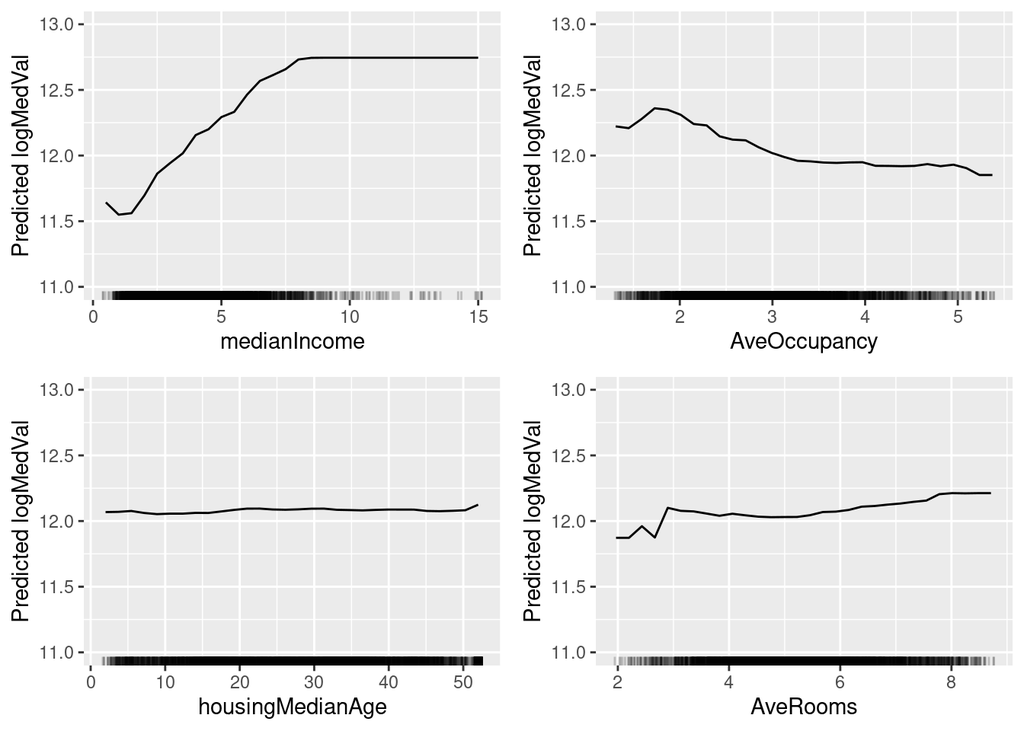

```r
# Create custom predict function that returns the predicted values as a vector
pred.gbm.fun <- function(model, newdata)
  predict(model, newdata=newdata, n.trees=5000)

mod <- Predictor$new(gbm.d.3,
                     data = ca.train,
                     predict.fun = pred.gbm.fun    # we need a custom predict function
                     )
eff <- FeatureEffect$new(mod,
          feature = "medianIncome",
          method = "pdp",
          grid.size = 30
          )
p1 <- plot(eff, ylim=c(11,13))
eff$set.feature("AveOccupancy")
p2 <- plot(eff, ylim=c(11,13))
eff$set.feature("housingMedianAge")
p3 <- plot(eff, ylim=c(11,13))
eff$set.feature("AveRooms")
p4 <- plot(eff, ylim=c(11,13))

gridExtra::grid.arrange(p1, p2, p3, p4, ncol = 2)
```

## Visualize Fits

- fitted values

```r
yhat.tree <- predict(ca.tree, ca.test)
yhat.rf <- predict(ca.rf, ca.test)
yhat.gbm <- predict(gbm.d.3, newdata=ca.test, n.trees=5000)
```

- and residuals.

```r
r.tree <- ca.test$logMedVal - yhat.tree
r.rf <- ca.test$logMedVal - yhat.rf
r.gbm <- ca.test$logMedVal - yhat.gbm
```

The code below is for help with visualization

- creates a palette of colors, and sets breaks to “bin” those colors,

```r
predcol <- heat.colors(9)[9:1]
rcol <- c('red','orange',0,'turquoise','blue')
predbreaks <- c(9,10,10.5,11,11.5,12,12.5,13,13.5,14.5)
residbreaks <- c(-3,-2,-1,1,2,3)
```

- maps bins to colors for predictions and residuals

```r
predmap <- function(y)
  return(predcol[cut(drop(y),predbreaks)])
residmap <- function(e)
  return(rcol[cut(drop(e), residbreaks)])
```

- and make a pre-set legend for shorthand later.

```r
pleg <- c("20k","100k","400k","1mil")
```

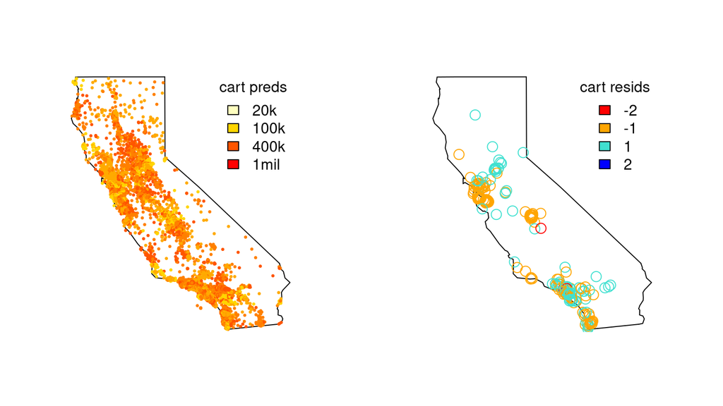

```r
par(mfrow=c(1,2))
map('state', 'california'); points(ca[,1:2], col=predmap(yhat.tree), pch=20, cex=.5)
legend("topr", title="cart preds", fill=predcol[c(1,4,7,9)], legend=pleg, bty="n")
map('state', 'california'); points(ca[,1:2], col=residmap(r.tree), cex=1.5)
legend("topr", title="cart resids", fill=rcol[-3], legend=c(-2,-1, 1,2), bty="n")
```

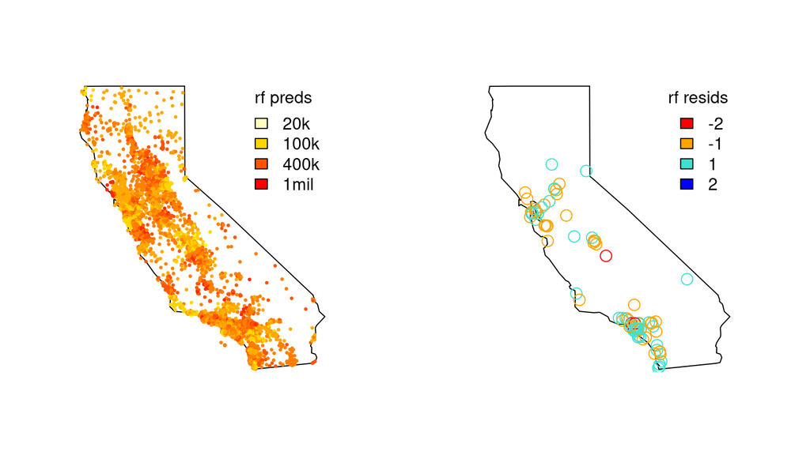

```r
par(mfrow=c(1,2))
map('state', 'california'); points(ca[,1:2], col=predmap(yhat.rf), pch=20, cex=.5)
legend("topr", title="rf preds", fill=predcol[c(1,4,7,9)], legend=pleg, bty="n")
map('state', 'california'); points(ca[,1:2], col=residmap(r.rf), cex=1.5)
legend("topr", title="rf resids", fill=rcol[-3], legend=c(-2,-1, 1,2), bty="n")
```

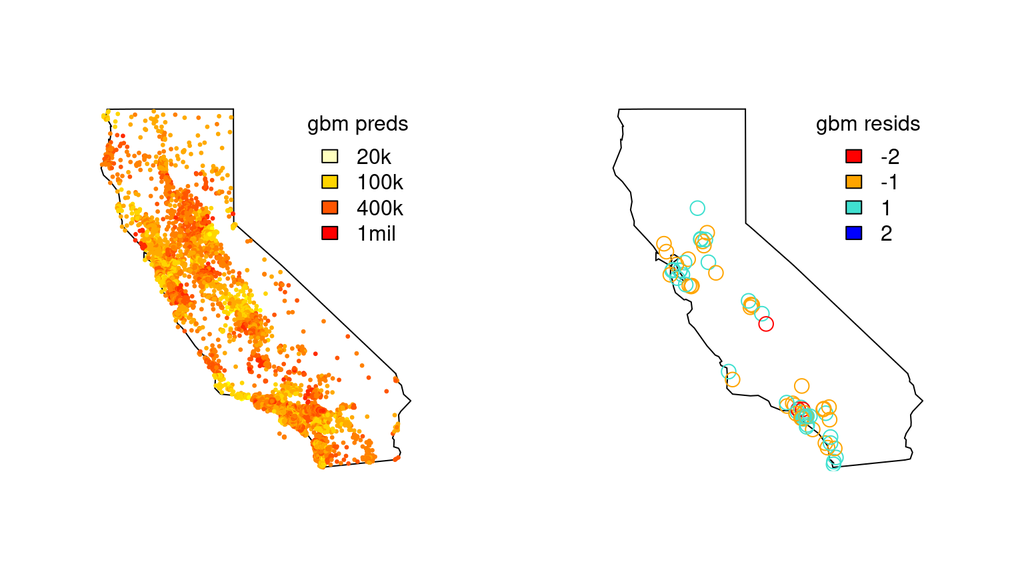

```r
par(mfrow=c(1,2))
map('state', 'california'); points(ca[,1:2], col=predmap(yhat.gbm), pch=20, cex=.5)
legend("topr", title="gbm preds", fill=predcol[c(1,4,7,9)], legend=pleg, bty="n")
map('state', 'california'); points(ca[,1:2], col=residmap(r.gbm), cex=1.5)
legend("topr", title="gbm resids", fill=rcol[-3], legend=c(-2,-1, 1,2), bty="n")
```

## Woah …

… random forests and boosting are super good!

- Who cares about interpretability when predictions are so accurate?
- Well some people do, but perhaps that’s what distinguishes stats from ML.
- Lets engineer a Monte Carlo experiment with training/testing partitions.

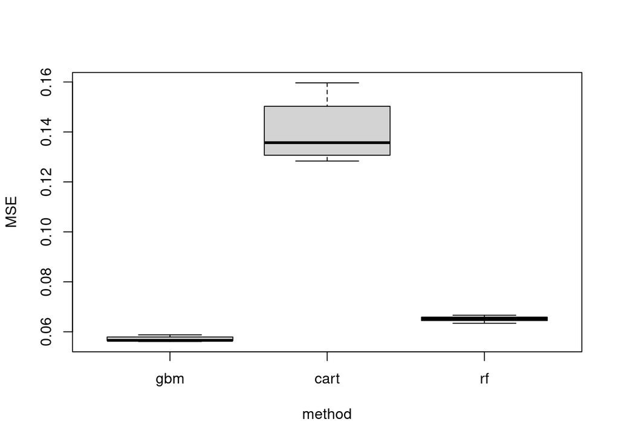

```r
mse <- data.frame(gbm=rep(NA, 10), cart=rep(NA, 10), rf=rep(NA, 10))
for(i in 1:10){

  ## training-testing split
  train <- sample(1:nrow(ca), 5000)

  ## gbm
  gbm.fit <-   gbm(logMedVal~., data=ca[train,], distribution='gaussian',
               interaction.depth=3,
               n.trees=5000,
               shrinkage=0.01,
               n.cores = 1,
               verbose = FALSE)
  yhat.gbm <- predict(gbm.fit, newdata=ca[-train,], n.trees=5000)
  mse$gbm[i] <- var(ca$logMedVal[-train] - yhat.gbm)

  ## cart via tree
  rt <- tree(logMedVal ~ ., data=ca[train,])
  yhat.rt <- predict(rt, newdata=ca[-train,])
  mse$cart[i] <- var(ca$logMedVal[-train] - yhat.rt)

  ## random forest
  rf <- randomForest(logMedVal ~ ., data=ca[train,], ntree=250, nodesize=25)
  yhat.rf <- predict(rf, newdata=ca[-train,])
  mse$rf[i] <- var(ca$logMedVal[-train] - yhat.rf)
}

boxplot(mse, xlab="method", ylab="MSE")
```